# Session 3 — Generalised Additive Models (GAM)

Smooth terms · edf · REML · checking k · binary GAMs · smooths by group · Lab 3

Community Medicine Workshop

## Where we are

- Session 2: you choose the **knots and df** yourself
- Today: a **GAM** lets the **data choose the smoothness** (with a penalty)
- By the end you can:
  - fit a GAM with `mgcv::gam()` and read **edf**
  - **check** the basis with `gam.check()`
  - fit a **binary** GAM
  - let a curve **differ by group**

# Topic 1 — The model

## A GAM for SBP

```r
g1 <- gam(sbp ~ s(age) + s(bmi) + s(activity) + salt + sex + smoker, data = ncd, method = "REML")
summary(g1)
```

- `s(x)`: a **penalised smooth**; `salt`, `sex`, `smoker` stay **linear**
- **method = “REML”**: chooses the **amount of smoothing** from the data
- **edf** = effective degrees of freedom: **1 = straight line**, larger = more curved. Age **3.9**, BMI **4.1**, activity **3.1**
- The parametric part reads like a normal regression (salt +0.65 mmHg per g/day)

## A GAM for SBP

```
Family: gaussian
Link function: identity

Formula:
sbp ~ s(age) + s(bmi) + s(activity) + salt + sex + smoker

Parametric coefficients:
            Estimate Std. Error t value Pr(>|t|)
(Intercept) 104.0292     0.6972 149.212  < 2e-16 ***
salt          0.6506     0.0722   9.012  < 2e-16 ***
sexMale       2.7612     0.3719   7.425 1.38e-13 ***
smoker        1.3587     0.4181   3.249  0.00117 **
---
Signif. codes:  0 '***' 0.001 '**' 0.01 '*' 0.05 '.' 0.1 ' ' 1

Approximate significance of smooth terms:
              edf Ref.df      F p-value
s(age)      3.899  4.835 202.74  <2e-16 ***
s(bmi)      4.076  5.056  64.45  <2e-16 ***
s(activity) 3.089  3.900  27.07  <2e-16 ***
---
Signif. codes:  0 '***' 0.001 '**' 0.01 '*' 0.05 '.' 0.1 ' ' 1

R-sq.(adj) =  0.311   Deviance explained = 31.4%
-REML =  15346  Scale est. = 125.21    n = 4000
```

## The curves

```r
par(mfrow = c(1, 3)); plot(g1, shade = TRUE, ylab = "Effect on SBP (mmHg)")
```

Each panel is the **partial effect** of one variable (others held fixed), with a **95% band**. Age **bends at about 45**, BMI **flattens** (diminishing returns), activity **flattens** too.

## The curves

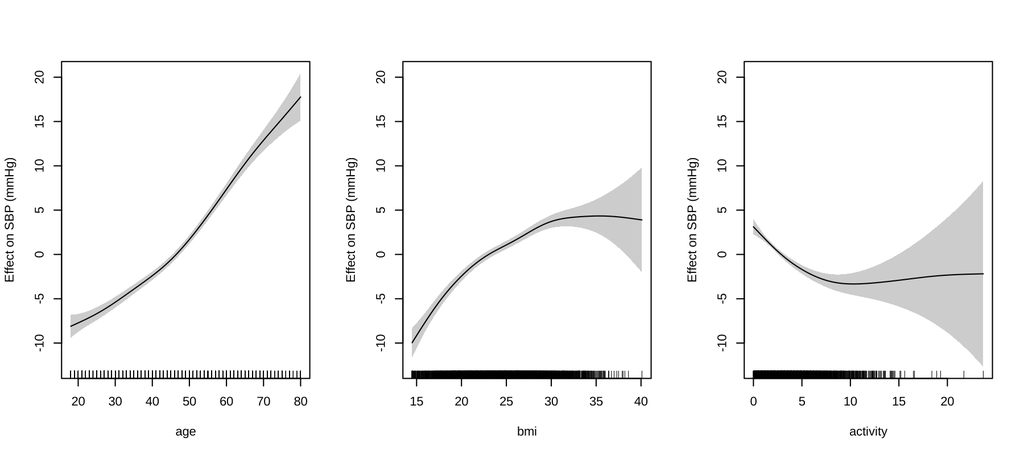

## Is it better than a straight line?

```r
AIC(m_l <- lm(sbp ~ age + bmi + salt + activity + sex + smoker, data = ncd), g1) |> round(0)
```

```
                                                                        df
m_l <- lm(sbp ~ age + bmi + salt + activity + sex + smoker, data = ncd)  8
g1                                                                      18
                                                                          AIC
m_l <- lm(sbp ~ age + bmi + salt + activity + sex + smoker, data = ncd) 30771
g1                                                                      30692
```

The GAM has **AIC 30,692** against **30,771** for the straight-line model: clearly better.

# Topic 2 — Checking

## Is k big enough?

```r
gam.check(g1)
```

```
Method: REML   Optimizer: outer newton
full convergence after 5 iterations.
Gradient range [-0.008028857,2.741888e-05]
(score 15345.67 & scale 125.212).
Hessian positive definite, eigenvalue range [0.927303,1996.511].
Model rank =  31 / 31

Basis dimension (k) checking results. Low p-value (k-index<1) may
indicate that k is too low, especially if edf is close to k'.

              k'  edf k-index p-value
s(age)      9.00 3.90    1.00    0.40
s(bmi)      9.00 4.08    1.00    0.41
s(activity) 9.00 3.09    0.99    0.39
```

- `k` is the **maximum** flexibility (default 10); `edf` should be **well below k’**
- The **k-index** is about **1** with **p ≈ 0.4**: k is **adequate**
- A **low k-index with a small p and edf close to k’**: refit with a **larger `k`**, e.g. `s(age, k = 15)`
- Also look at the **residual plots** (normality, constant variance)

# Topic 3 — Binary outcomes and groups

## A logistic GAM

```r
g2 <- gam(cvd10 ~ s(age) + s(bmi) + sex + smoker, data = ncd, family = binomial, method = "REML")
round(summary(g2)$s.table, 2)
```

```
        edf Ref.df Chi.sq p-value
s(age) 1.00   1.00 263.58       0
s(bmi) 4.97   6.07 230.95       0
```

```r
plot(g2, select = 2, trans = plogis, shift = coef(g2)[1], seWithMean = TRUE, xlab = "BMI", ylab = "10-year CVD risk")
```

The BMI smooth has **edf 5.0**: very curved (**U-shaped**); the age smooth has **edf 1.0**: a **straight line on the logit scale**. The GAM **discovered both** without being told.

## A logistic GAM

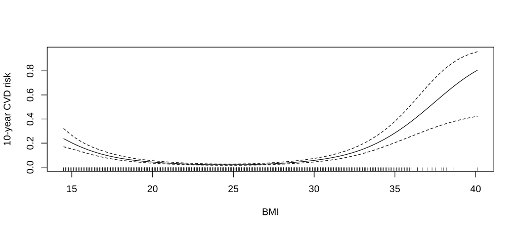

## A curve for each group

```r
g3 <- gam(sbp ~ s(age, by = sex) + sex + s(bmi) + s(activity) + salt + smoker, data = ncd, method = "REML")
round(AIC(g1, g3), 0)
```

```
   df   AIC
g1 18 30692
g3 21 30686
```

- `s(age, by = sex)`: **a separate age curve for men and for women**
- AIC **30,686 vs 30,692**: a tiny gain, so the curves are **alike**: keep the simpler model
- Keep **`sex` as a main effect** too when you use `by = sex`

## GAM or natural spline?

```r
nd <- data.frame(age = c(30, 45, 70), bmi = mean(ncd$bmi), salt = mean(ncd$salt), activity = mean(ncd$activity), sex = factor("Male", levels = levels(ncd$sex)), smoker = 0)
m_ns <- lm(sbp ~ ns(age, df = 4) + bmi + salt + activity + sex + smoker, data = ncd)
round(cbind(gam = predict(g1, nd), ns = predict(m_ns, nd)), 1)
```

```
    gam    ns
1 107.7 107.8
2 112.5 112.2
3 126.0 125.7
```

**Practically identical** (107.7 vs 107.8; 112.5 vs 112.2; 126.0 vs 125.7). The GAM **chooses the df for you**; a spline with a few df is **easier to explain and to refit** in other software. Both are fine; **report the plot**.

## 🔧 Switch to R — Lab 3

**File:** `curves-workshop/labs/lab3_gam.R`

- GAM for SBP, smooth plots, AIC
- `gam.check`, a logistic GAM
- smooth by sex, GAM vs natural spline

**Time:** 40 minutes · answer the Q questions in the comments

## Self-check quiz (1/5)

In a GAM summary a smooth term has an edf of 1.0. What does that mean?

- The curve is essentially a straight line
- The smooth has a single knot at the median
- The variable explains one percent of the variance
- The smooth has failed and the model must be refitted

## Self-check quiz (2/5)

What does method = “REML” do in gam()?

- It removes the random effects from the model before fitting
- It chooses the amount of smoothing from the data
- It refits the model using only the residuals from the first fit
- It rounds the smooth terms to whole degrees of freedom

## Self-check quiz (3/5)

gam.check shows a low k-index with a small p-value, and the edf is close to k’. What should you do?

- Reduce k, because the curve already has too many degrees of freedom in it
- Replace the smooth by a straight line in the model and refit the data
- Ignore it, because k only affects the plot and does not affect the fit
- Refit with a larger k, because the basis is too small for the curve

## Self-check quiz (4/5)

The GAM and a natural spline with 4 df give almost the same predictions. What does this tell you?

- A spline with a few df is often enough; the GAM picks its own df
- The GAM is wrong, since it should give a curve different from the spline
- Both models are overfitted to the same noise in the sample of adults
- The data must be linear, since the two curves agree so closely with each other

## Self-check quiz (5/5)

What does s(age, by = sex) give?

- The age smooth multiplied by the sex variable
- Age adjusted for sex before the smooth is fitted
- A separate age curve for each sex
- One age curve, shifted up or down for each sex

## Score and take-home

**Your score:**

- **`gam(y ~ s(x) + ..., method = "REML")`**
- **edf** 1 = straight line; higher = more curved
- `gam.check`: k-index, edf vs k’
- Binary outcome: `family = binomial`; plot with `trans = plogis`
- `by =` for group-specific curves; **plots are the result**

**Next:** Session 4: interaction and effect modification